# Sample Size Calculation

Sebastian Quirarte

September 2023

**Programming Language**: R | **Packages**: ggplot2, ggthemes

The goal of this document is to provide a template in R that can calculate the sample size needed for clinical trials and other experiments based on a range of specified values and a set type l error ($\alpha$), type two error ($\beta$), and statistical power ($1 - \beta$). A range of the means or proportions of the treatment group of interest can be established and all sample sizes calculated, stored in a data frame, and plotted.

**Group A is considered the ‘new treatment group’ and the sample size calculated is for EACH of the two treatment arms/groups. In other words, the total sample size is equal to double the calculated value**

*Source and inspiration:* HyLown Consulting LLC (2022), https://powerandsamplesize.com/

First, let’s remove previous variables as part of good practices in R, and load the necessary packages for the ggplot() and themes() functions.

```r
rm(list = ls())
pkgs <- (c("ggplot2", "ggthemes")) # ggplot, theme_minimal()
lapply(pkgs, require, character.only = TRUE)
```

# 1 Compare Two Means

## 1.1 Equality

Equality tests aim to prove if the means of two groups are different. Suppose the two groups are ‘A’ and ‘B’, and we collect a sample from both groups – i.e. we have two samples. We perform a two-sample test to determine whether the mean in group A ($μ_{A}$), is different from the mean in group B ($μ_{B}$).

The hypotheses are:

$$H_{0}: \mu_{A} - \mu_{B} = 0$$
$$H_{1}: \mu_{A} - \mu_{B} ≠ 0$$

Let’s load up our necessary variables

```r
muA = 5 # group A mean (new treatment)
muB = 10 # group B mean
sd = 10 # standard deviation
kappa = 1 # sampling ratio
alpha = 0.05 # type 1 error
beta = 0.20 # type 2 error
```

We can set a range of treatment group means ($μ_{A}$) that we want to plot with their respective sample sizes.

```r
range_meanA = seq(1, 8, 0.1) # (start, stop, step)
```

Let’s create a data frame with this range of means and an empty column for sample sizes (n).

```r
df <- data.frame("meanA"=range_meanA, "n"=0)
```

This for loop calculates the sample sizes for each of the means in our selected range and adds them to our data frame.

```r
# Sets counter variable to iterate through each row
count = 1
# Calculates sample size for each mean of group A and adds value to data frame
for (i in range_meanA){
  muA = i
  nB = ceiling((1+1/kappa)*(sd*(qnorm(1-alpha/2)+qnorm(1-beta))/(muA-muB))^2)
  df[count, 2] = nB
  count = count + 1
}
```

Here’s a look at our data frame of calcualted sample sizes per treatment arm:

```r
head(df)
```

```
##   meanA  n
## 1   1.0 20
## 2   1.1 20
## 3   1.2 21
## 4   1.3 21
## 5   1.4 22
## 6   1.5 22
```

```r
tail(df)
```

```
##    meanA   n
## 66   7.5 252
## 67   7.6 273
## 68   7.7 297
## 69   7.8 325
## 70   7.9 356
## 71   8.0 393
```

Finally, we can create a plot of the sample sizes based on the range of means of interest.

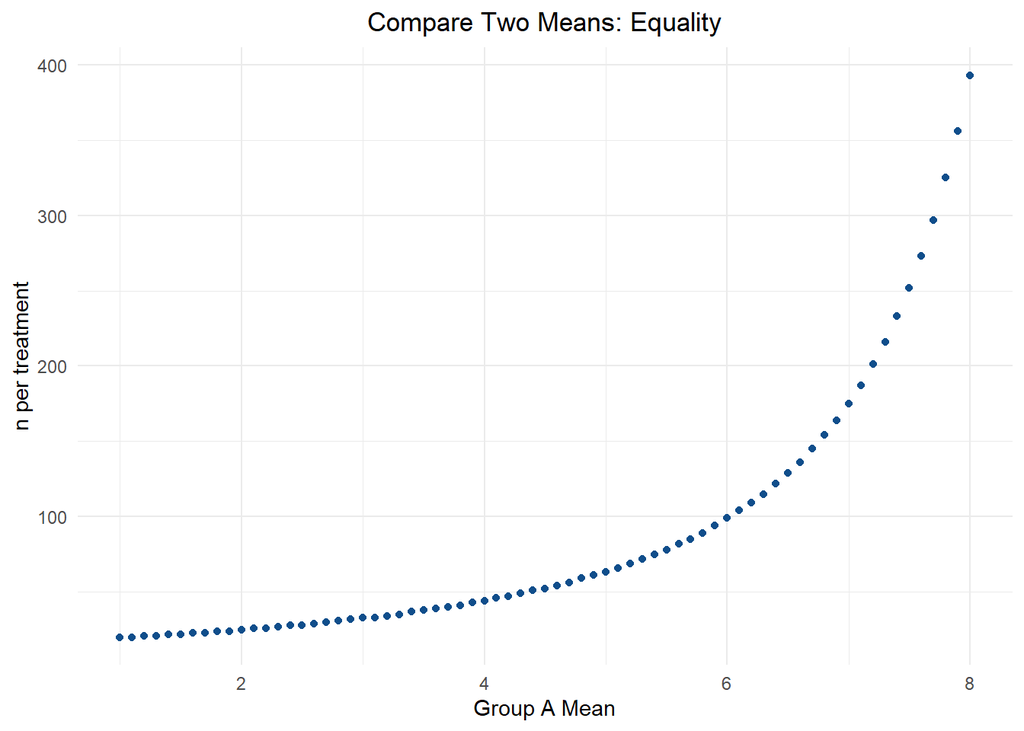

```r
ggplot(df, aes(x = meanA, y = n)) + geom_point(color="dodgerblue4") +
  theme_minimal() + ggtitle("Compare Two Means: Equality") + theme(plot.title = element_text(hjust = 0.5)) + xlab("Group A Mean") + ylab("n per treatment")
```

## 1.2 Non-Inferiority or Superiority

Non-inferiority and superiority tests aim to prove that a new treatment is either non-inferior or superior to another treatment, by a set margin known as a margin of non-inferiority ($-\delta$) or margin of superiority ($\delta$). In this setting, we wish to test whether the mean in group ‘A’, $μ_{A}$, is non-inferior/superior to the mean in group ‘B’, $μ_{B}$. We collect a sample from both groups, and thus will conduct a two-sample test. The idea is that statistically significant differences between the means may not be of interest unless the difference is greater than a threshold, $\delta$. This is particularly popular in clinical studies, where the margin is chosen based on clinical judgement and subject-domain knowledge.

The hypotheses to test are:

$$H_{0}: \mu_{A} - \mu_{B} ≤ \delta$$
$$H_{1}: \mu_{A} - \mu_{B} > \delta$$

Let’s load up our necessary variables

```r
muA = 5 # group A mean (new treatment)
muB = 5 # group B mean
sd = 10 # standard deviation
delta = 5 # non-inferiority (-) or superiority (+) margin
kappa = 1 # sampling ratio
alpha = 0.05 # type 1 error
beta = 0.20 # type 2 error
```

We can set a range of treatment group means ($μ_{A}$) that we want to plot with their respective sample sizes.

```r
range_meanA = seq(5, 8, 0.1) # (start, stop, step)
```

Let’s create a data frame with this range of means and an empty column for sample sizes (n).

```r
df <- data.frame("meanA"=range_meanA, "n"=0)
```

This for loop calculates the sample sizes for each of the means in our selected range and adds them to our data frame.

```r
# Sets counter variable to iterate through each row
count = 1
# Calculates sample size for each mean of group A and adds value to data frame
for (i in range_meanA){
  muA = i
  nB = ceiling((1+1/kappa)*(sd*(qnorm(1-alpha)+qnorm(1-beta))/(muA-muB-delta))^2)
  df[count, 2] = nB
  count = count + 1
}
```

Here’s a look at our data frame of calculated sample sizes per treatment arm:

```r
head(df)
```

```
##   meanA  n
## 1   5.0 50
## 2   5.1 52
## 3   5.2 54
## 4   5.3 56
## 5   5.4 59
## 6   5.5 62
```

```r
tail(df)
```

```
##    meanA   n
## 26   7.5 198
## 27   7.6 215
## 28   7.7 234
## 29   7.8 256
## 30   7.9 281
## 31   8.0 310
```

Finally, we can creates a plot of the sample sizes based on the range of means of interest.

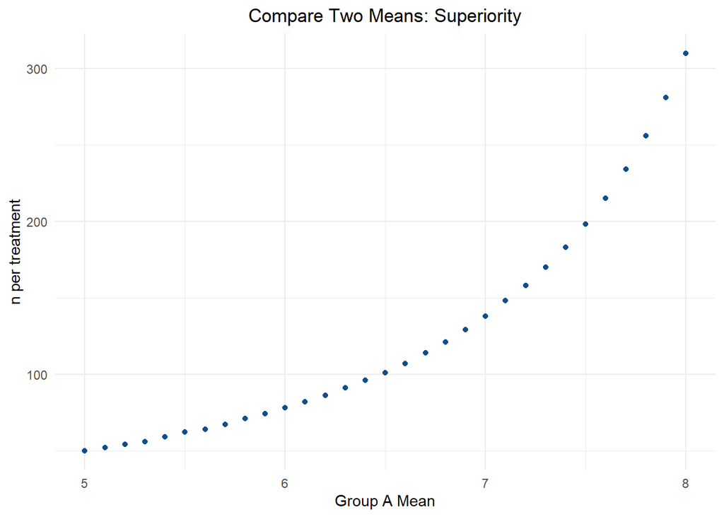

```r
ggplot(df, aes(x = meanA, y = n)) + geom_point(color="dodgerblue4") +
  theme_minimal() + ggtitle("Compare Two Means: Superiority") + theme(plot.title = element_text(hjust = 0.5)) + xlab("Group A Mean") + ylab("n per treatment")
```

If we change the sign of our margin from $\delta$ to -$\delta$, we can see this same result if applied to a non-inferiority trial instead of superiority.

```r
muA = 5 # group A mean (new treatment)
muB = 5 # group B mean
sd = 10 # standard deviation
delta = -5 # non-inferiority (-) or superiority (+) margin
kappa = 1 # sampling ratio
alpha = 0.05 # type 1 error
beta = 0.20 # type 2 error
```

```r
range_meanA = seq(4, 8, 0.1) # (start, stop, step)
```

```r
df <- data.frame("meanA"=range_meanA, "n"=0)
```

```r
# Sets counter variable to iterate through each row
count = 1
# Calculates sample size for each mean of group A and adds value to data frame
for (i in range_meanA){
  muA = i
  nB = ceiling((1+1/kappa)*(sd*(qnorm(1-alpha)+qnorm(1-beta))/(muA-muB-delta))^2)
  df[count, 2] = nB
  count = count + 1
}
```

```r
head(df)
```

```
##   meanA  n
## 1   4.0 78
## 2   4.1 74
## 3   4.2 71
## 4   4.3 67
## 5   4.4 64
## 6   4.5 62
```

```r
tail(df)
```

```
##    meanA  n
## 36   7.5 22
## 37   7.6 22
## 38   7.7 21
## 39   7.8 21
## 40   7.9 20
## 41   8.0 20
```

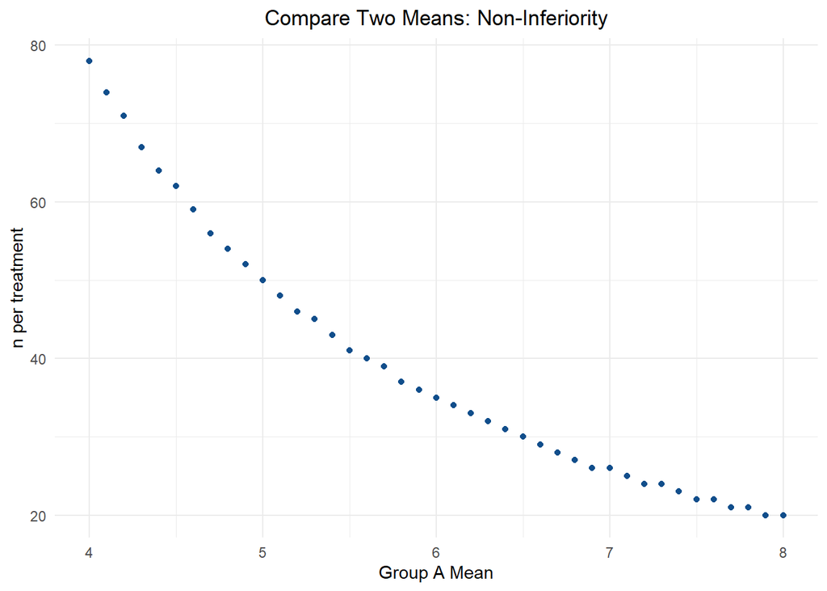

```r
ggplot(df, aes(x = meanA, y = n)) + geom_point(color="dodgerblue4") +
  theme_minimal() + ggtitle("Compare Two Means: Non-Inferiority") + theme(plot.title = element_text(hjust = 0.5)) + xlab("Group A Mean") + ylab("n per treatment")
```

## 1.3 Equivalence

An equivalence test is useful when we wish to test whether the means of two groups are equivalent, without concern for which group’s mean is larger. Suppose we collect a sample from a group ‘A’ and a group ‘B’; that is we collect two samples and will conduct a two-sample test. For example, we may wish to test whether a new product is equivalent to an existing, industry standard product. Here, the ‘burden of proof’, so to speak, falls on the new product; that is, equivalence is actually represented by the alternative, rather than the null hypothesis.

The hypotheses to test are:

$$H_{0}: |\mu_{A} - \mu_{B}| ≥ \delta$$
$$H_{1}: |\mu_{A} - \mu_{B}| < \delta$$

Let’s load up our necessary variables

```r
muA = 5 # group A mean (new treatment)
muB = 4 # group B mean
sd = 10 # standard deviation
delta = 5 # equivalence margin
kappa = 1 # sampling ratio
alpha = 0.05 # type 1 error
beta = 0.20 # type 2 error
```

We can set a range of treatment group means ($μ_{A}$) that we want to plot with their respective sample sizes.

```r
range_meanA = seq(4, 7, 0.1) # (start, stop, step)
```

Let’s create a data frame with this range of means and an empty column for sample sizes (n).

```r
df <- data.frame("meanA"=range_meanA, "n"=0)
```

This for loop calculates the sample sizes for each of the means in our selected range and adds them to our data frame.

```r
# Sets counter variable to iterate through each row
count = 1
# Calculates sample size for each mean of group A and adds value to data frame
for (i in range_meanA){
  muA = i
  nB = ceiling((1+1/kappa)*(sd*(qnorm(1-alpha)+qnorm(1-beta/2))/(abs(muA-muB)-delta))^2)
  df[count, 2] = nB
  count = count + 1
}
```

Here’s a look at our data frame:

```r
head(df)
```

```
##   meanA  n
## 1   4.0 69
## 2   4.1 72
## 3   4.2 75
## 4   4.3 78
## 5   4.4 81
## 6   4.5 85
```

```r
tail(df)
```

```
##    meanA   n
## 26   6.5 275
## 27   6.6 298
## 28   6.7 324
## 29   6.8 354
## 30   6.9 389
## 31   7.0 429
```

Finally, we can creates a plot of the sample sizes based on the range of means of interest.

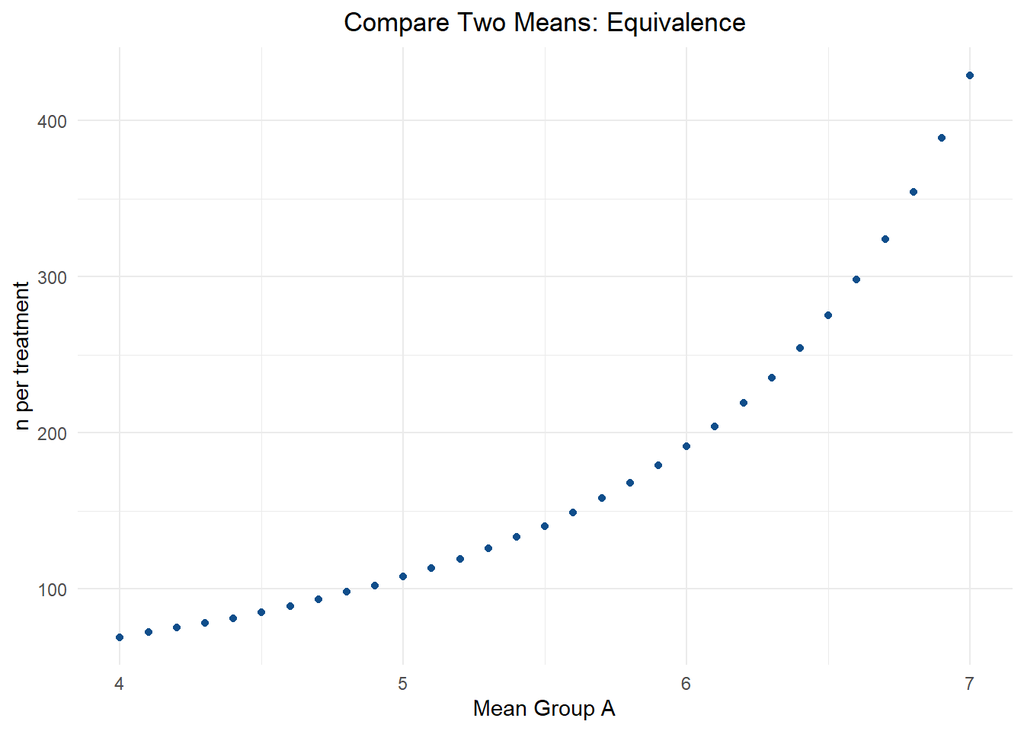

```r
ggplot(df, aes(x = meanA, y = n)) + geom_point(color="dodgerblue4") +
  theme_minimal() + ggtitle("Compare Two Means: Equivalence") + theme(plot.title = element_text(hjust = 0.5)) + xlab("Mean Group A") + ylab("n per treatment")
```

# 2 Compare Two Proportions

## 2.1 Equality

Equality tests aim to prove if the proportions of two groups are different. Suppose the two groups are ‘A’ and ‘B’, and we collect a sample from both groups – i.e. we have two samples. We perform a two-sample test to determine whether the proportion in group A ($p_{A}$) is different from the proportion in group B ($p_{B}$).

The hypotheses are:

$$H_{0}: p_{A} - p_{B} = 0$$
$$H_{1}: p_{A} - p_{B} ≠ 0$$

Let’s load up our necessary variables

```r
pA = 0.65 # group A proportion (new treatment)
pB = 0.85 # group B proportion
kappa = 1 # sampling ratio
alpha = 0.05 # type 1 error
beta = 0.20 # type 2 error
```

We can set a range of treatment group proportions ($p_{A}$) that we want to plot with their respective sample sizes.

```r
range_propA = seq(0.65, 0.78, 0.01) # (start, stop, step)
```

Let’s create a data frame with this range of proportions and an empty column for sample sizes (n).

```r
df <- data.frame("propA"=range_propA, "n"=0)
```

This for loop calculates the sample sizes for each of the means in our selected range and adds them to our data frame.

```r
# Sets counter variable to iterate through each row
count = 1
# Calculates sample size for each proportion of group A and adds value to data frame
for (i in range_propA){
  pA = i
  nB = ceiling((pA*(1-pA)/kappa+pB*(1-pB))*((qnorm(1-alpha/2)+qnorm(1-beta))/(pA-pB))^2)
  df[count, 2] = nB
  count = count + 1
}
```

Here’s a look at our data frame:

```r
head(df)
```

```
##   propA   n
## 1  0.65  70
## 2  0.66  77
## 3  0.67  85
## 4  0.68  94
## 5  0.69 105
## 6  0.70 118
```

```r
tail(df)
```

```
##    propA   n
## 9   0.73 177
## 10  0.74 208
## 11  0.75 248
## 12  0.76 301
## 13  0.77 374
## 14  0.78 480
```

Finally, we can creates a plot of the sample sizes based on the range of means of interest.

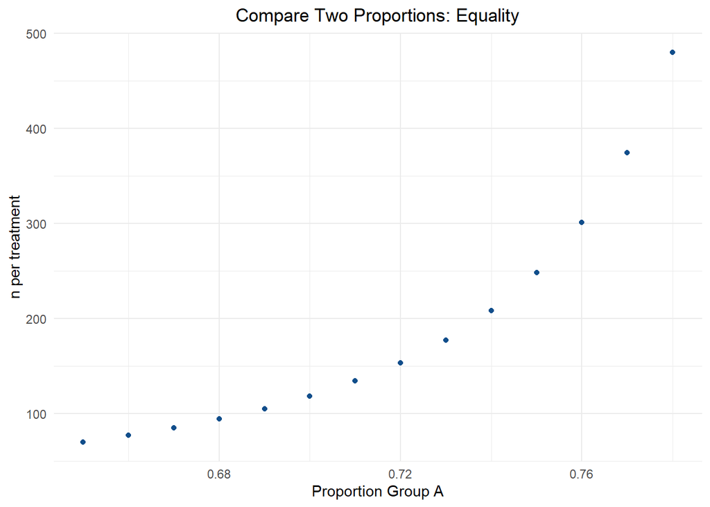

```r
ggplot(df, aes(x = propA, y = n)) + geom_point(color="dodgerblue4") +
  theme_minimal() + ggtitle("Compare Two Proportions: Equality") + theme(plot.title = element_text(hjust = 0.5)) + xlab("Proportion Group A") + ylab("n per treatment")
```

## 2.2 Non-inferiority or Superiority

Non-inferiority and superiority tests aim to prove that a new treatment is either not-inferior or superior compared to another treatment, by a set margin known as a margin of non-inferiority ($-\delta$) or margin of superiority ($\delta$). In this setting, we wish to test whether the proportion in group ‘A’, $p_{A}$, is non-inferior/superior to the proportion in group ‘B’, $p_{B}$. We collect a sample from both groups, and thus will conduct a two-sample test. The idea is that statistically significant differences between the proportions may not be of interest unless the difference is greater than a threshold, $\delta$. This is particularly popular in clinical studies, where the margin is chosen based on clinical judgement and subject-domain knowledge.

The hypotheses to test are:

$$H_{0}: p_{A} - p_{B} ≤ \delta$$
$$H_{1}: p_{A} - p_{B} > \delta$$

Let’s load up our necessary variables

```r
pA = 0.85 # group A proportion (new treatment)
pB = 0.65 # group B proportion
delta = -0.10 # non-inferiority (-) or superiority (+) margin
kappa = 1 # sampling ratio
alpha = 0.05 # type 1 error
beta = 0.20 # type 2 error
```

We can set a range of treatment group proportions ($p_{A}$) that we want to plot with their respective sample sizes.

```r
range_propA = seq(0.65, 0.85, 0.01) # (start, stop, step)
```

Let’s create a data frame with this range of means and an empty column for sample sizes (n).

```r
df <- data.frame("propA"=range_propA, "n"=0)
```

This for loop calculates the sample sizes for each of the means in our selected range and adds them to our data frame.

```r
# Sets counter variable to iterate through each row
count = 1
# Calculates sample size for each proportion of group A and adds value to data frame
for (i in range_propA){
  pA = i
  nB = ceiling((pA*(1-pA)/kappa+pB*(1-pB))*((qnorm(1-alpha)+qnorm(1-beta))/(pA-pB-delta))^2)
  df[count, 2] = nB
  count = count + 1
}
```

Here’s a look at our data frame:

```r
head(df)
```

```
##   propA   n
## 1  0.65 282
## 2  0.66 231
## 3  0.67 193
## 4  0.68 163
## 5  0.69 140
## 6  0.70 121
```

```r
tail(df)
```

```
##    propA  n
## 16  0.80 39
## 17  0.81 35
## 18  0.82 32
## 19  0.83 30
## 20  0.84 27
## 21  0.85 25
```

Finally, we can creates a plot of the sample sizes based on the range of means of interest.

[figure not shown]

```r
ggplot(df, aes(x = propA, y = n)) + geom_point(color="dodgerblue4") +
  theme_minimal() + ggtitle("Compare Two Proportions: Superiority") +
  theme(plot.title = element_text(hjust = 0.5)) + xlab("Proportion Group A") +
  ylab("n per treatment")
```

```r
pA = 0.65 # group A proportion (new treatment)
pB = 0.85 # group B proportion
delta = 0.10 # non-inferiority (-) or superiority (+) margin
kappa = 1 # sampling ratio
alpha = 0.05 # type 1 error
beta = 0.20 # type 2 error
```

```r
range_propA = seq(0.65, 0.85, 0.01) # (start, stop, step)
```

```r
df <- data.frame("propA"=range_propA, "n"=0)
```

```r
# Sets counter variable to iterate through each row
count = 1
# Calculates sample size for each proportion of group A and adds value to data frame
for (i in range_propA){
  pA = i
  nB = ceiling((pA*(1-pA)/kappa+pB*(1-pB))*((qnorm(1-alpha)+qnorm(1-beta))/(pA-pB-delta))^2)
  df[count, 2] = nB
  count = count + 1
}
```

```r
head(df)
```

```
##   propA  n
## 1  0.65 25
## 2  0.66 26
## 3  0.67 28
## 4  0.68 30
## 5  0.69 32
## 6  0.70 34
```

```r
tail(df)
```

```
##    propA   n
## 16  0.80  79
## 17  0.81  89
## 18  0.82 101
## 19  0.83 116
## 20  0.84 134
## 21  0.85 158
```

[figure not shown]

```r
ggplot(df, aes(x = propA, y = n)) + geom_point(color="dodgerblue4") +
  theme_minimal() + ggtitle("Compare Two Proportions: Non-Inferiority") + theme(plot.title = element_text(hjust = 0.5)) + xlab("Proportion Group A") + ylab("n per treatment")
```

## 2.3 Equivalence

An equivalence test is useful when we wish to test whether the proportions of two groups are equivalent, without concern of which group’s proportion is larger. Suppose we collect a sample from a group ‘A’ and a group ‘B’; that is we collect two samples, and will conduct a two-sample test. For example, we may wish to test whether a new product is equivalent to an existing, industry standard product. Here, the ‘burden of proof’, so to speak, falls on the new product; that is, equivalence is actually represented by the alternative, rather than the null hypothesis.

The hypotheses to test are:

$$H_{0}: |p_{A} - p_{B}| ≥ \delta$$
$$H_{1}: |p_{A} - p_{B}| < \delta$$

Let’s load up our necessary variables

```r
pA = 0.65 # group A proportion (new treatment)
pB = 0.85 # group B proportion
delta = 0.05 # equivalence margin
kappa = 1 # sampling ratio
alpha = 0.05 # type 1 error
beta = 0.20 # type 2 error
```

We can set a range of treatment group proportions ($p_{A}$) that we want to plot with their respective sample sizes.

```r
range_propA = seq(0.60, 0.75, 0.01) # (start, stop, step)
```

Let’s create a data frame with this range of means and an empty column for sample sizes (n).

```r
df <- data.frame("propA"=range_propA, "n"=0)
```

This for loop calculates the sample sizes for each of the means in our selected range and adds them to our data frame.

```r
# Sets counter variable to iterate through each row
count = 1
# Calculates sample size for each proportion of group A and adds value to data frame
for (i in range_propA){
  pA = i
  nB = ceiling((pA*(1-pA)/kappa+pB*(1-pB))*((qnorm(1-alpha)+qnorm(1-beta/2))/(abs(pA-pB)-delta))^2)
  df[count, 2] = nB
  count = count + 1
}
```

Here’s a look at our data frame:

```r
head(df)
```

```
##   propA   n
## 1  0.60  79
## 2  0.61  87
## 3  0.62  96
## 4  0.63 107
## 5  0.64 120
## 6  0.65 136
```

```r
tail(df)
```

```
##    propA    n
## 11  0.70  290
## 12  0.71  353
## 13  0.72  441
## 14  0.73  568
## 15  0.74  761
## 16  0.75 1080
```

Finally, we can creates a plot of the sample sizes based on the range of means of interest.

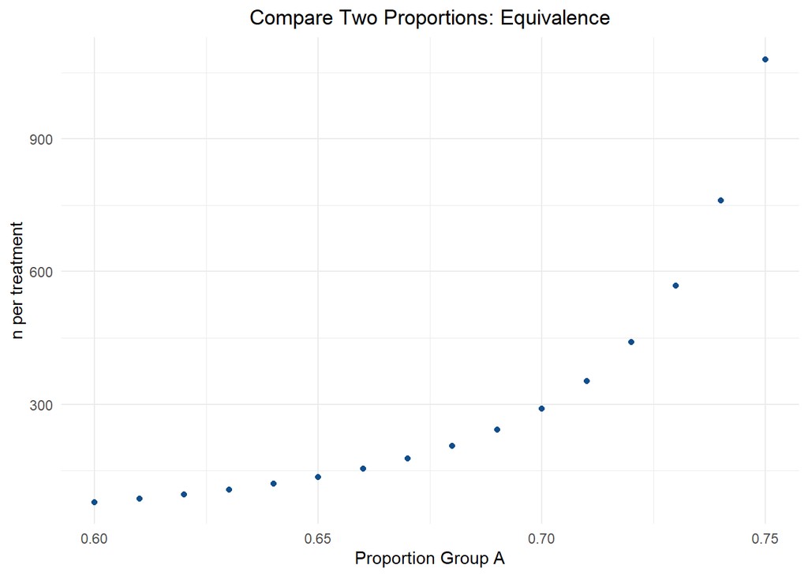

```r
ggplot(df, aes(x = propA, y = n)) + geom_point(color="dodgerblue4") +
  theme_minimal() + ggtitle("Compare Two Proportions: Equivalence") + theme(plot.title = element_text(hjust = 0.5)) + xlab("Proportion Group A") + ylab("n per treatment")
```

# 3 Version Control

September 13, 2023 – Version 1.1 – spelling and added titles to plots.

September 9, 2023 – Version 1.0 – Creation of first finished version.